# Plots from Simulations (500 reps)

# Simulation setup

- Strata 1: D = 0.05 ; sigma = 200 m ; L0 = 2
- Strata 2: D = 0.0033 ; sigma = 3000 m ; L0 = 0.133

# Relative bias plots

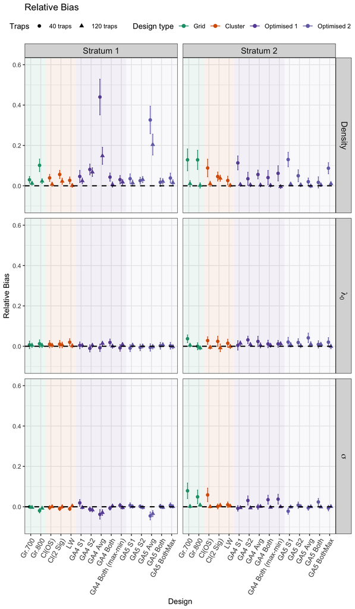

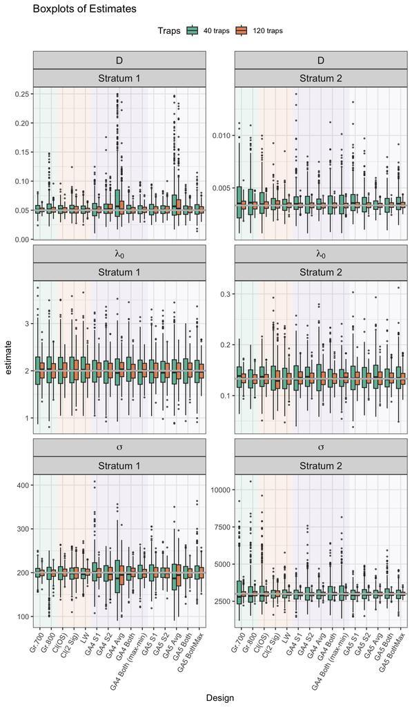

## By trap level

**40 traps**

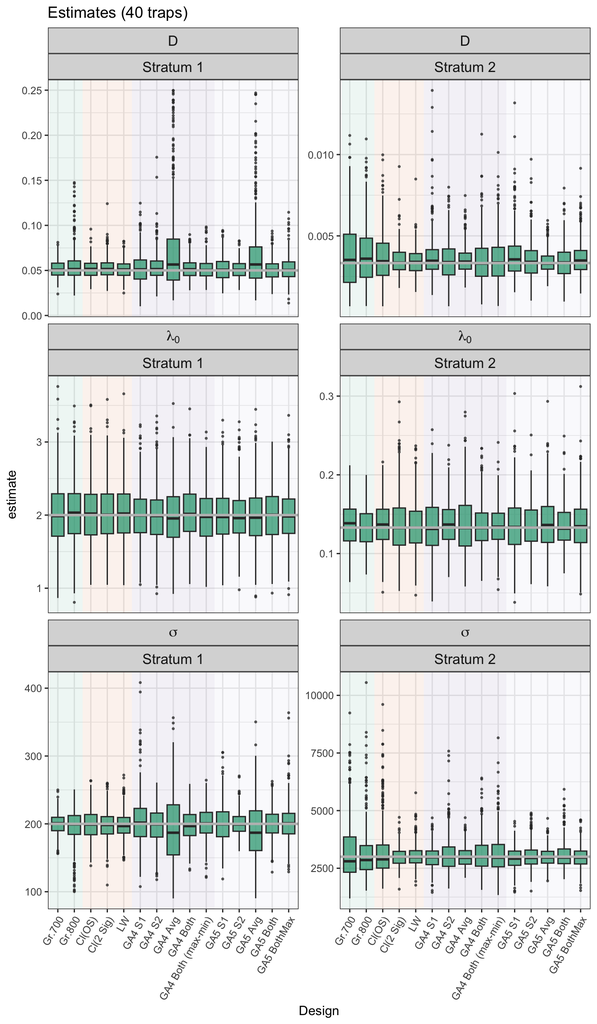

**120 traps**

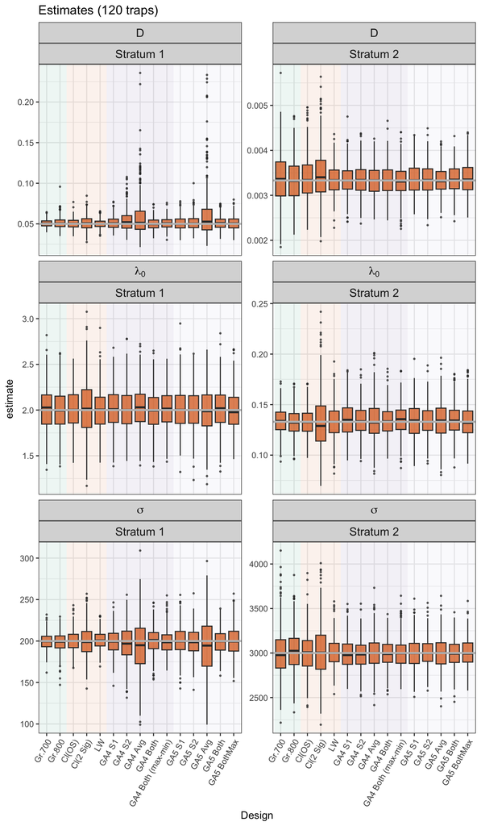

## General comments - bias

### Grids

- slight positive bias in D for both strata, slightly less for S1 with 700 m spacing
- very slight positive bias in $\sigma$ for S2
- dbn of D ests skew to the right particularly for S1 at 800 m spacing
- for 800 m spacing the dbn of $\sigma$ ests negatively skewed for S1, and positively skewed for S2 at both 700 and 800

### Clusters

- with OS spacing there is very slight positive bias in D for S1 and a bit more for S2 ; there is also slight positive bias in $\sigma$ for S2
- with 2 $\sigma$ spacing and the lacework design there is very slight positive bias in D that is balanced across the strata

### GA4

#### S1 values

- Some positive skewness in D (more for S2), slight for L0 and sigma (more for S1)

#### S2 values

- Slight positive skew in D and L0 for both strata, for sigma only for S2
- With 120 traps slight +ve skew in D for S1 but others fairly symmetrical

#### Avg values

- Substantial positive skewness and bias in D, especially for S1. Even with 120 traps there is still positive bias of around 15%.
- Also slight -ve bias in $\sigma$ for S1

#### Both values

- With 40 traps, slight +ve bias and skew in D, more so for S2
- Max-min similar

### GA5

- similar pattern to GA4 though when using average values slightly less bias in D for S1 for 40 traps and slightly more with 120 traps

### Lacework

- Very slight positive bias and skew in D but balanced across strata and mostly more symmetrical dbns for all parameters

# Relative SE plots

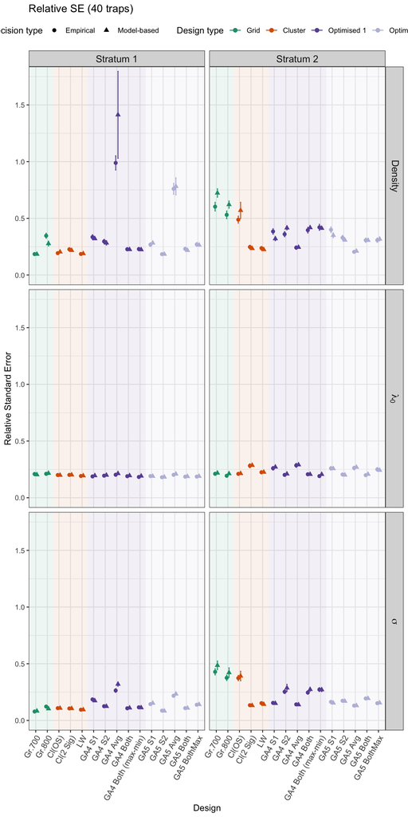

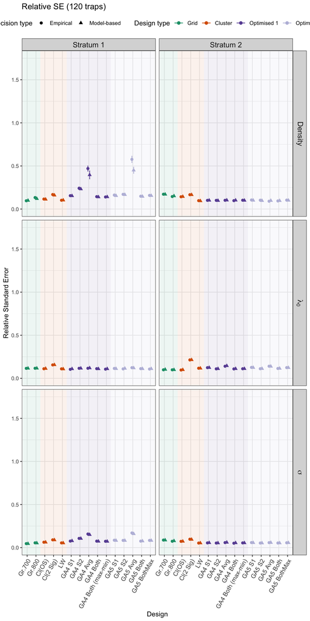

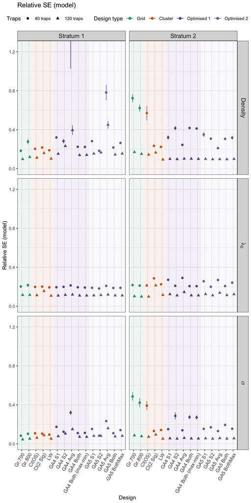

# Coverage plots

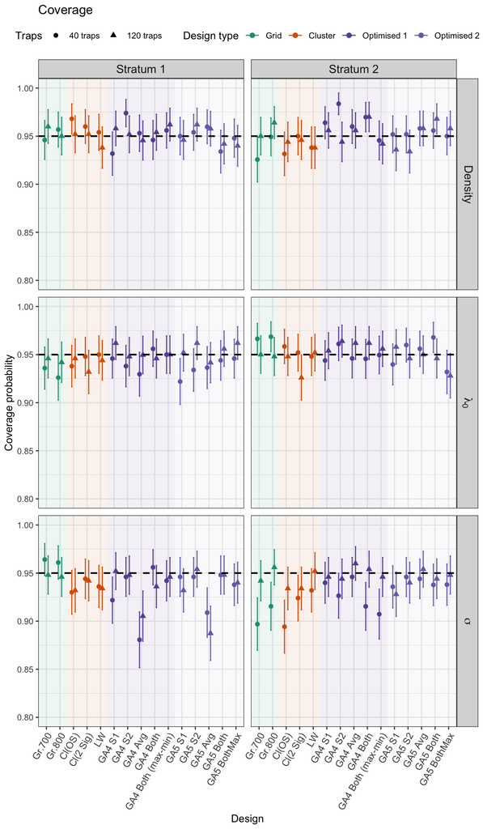

# Boxplots of relative standard errors

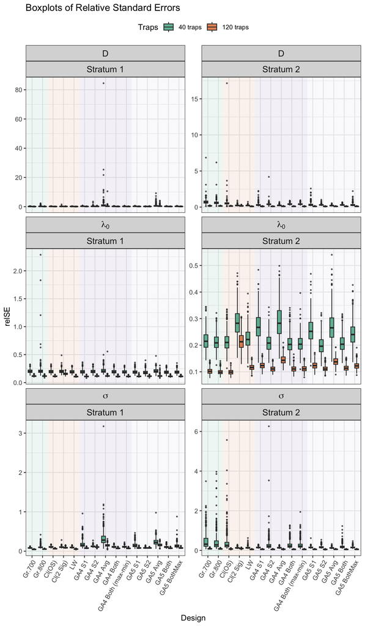

## Grids with 800 m spacing

**Density**

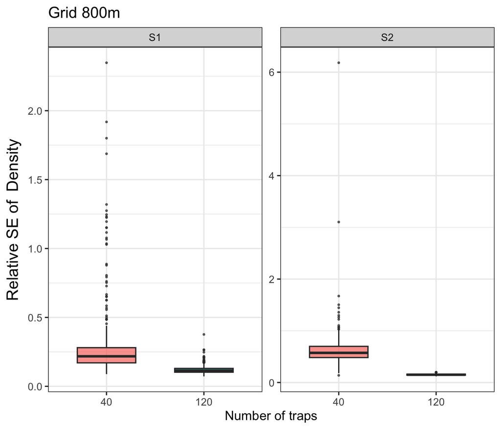

**λ₀**

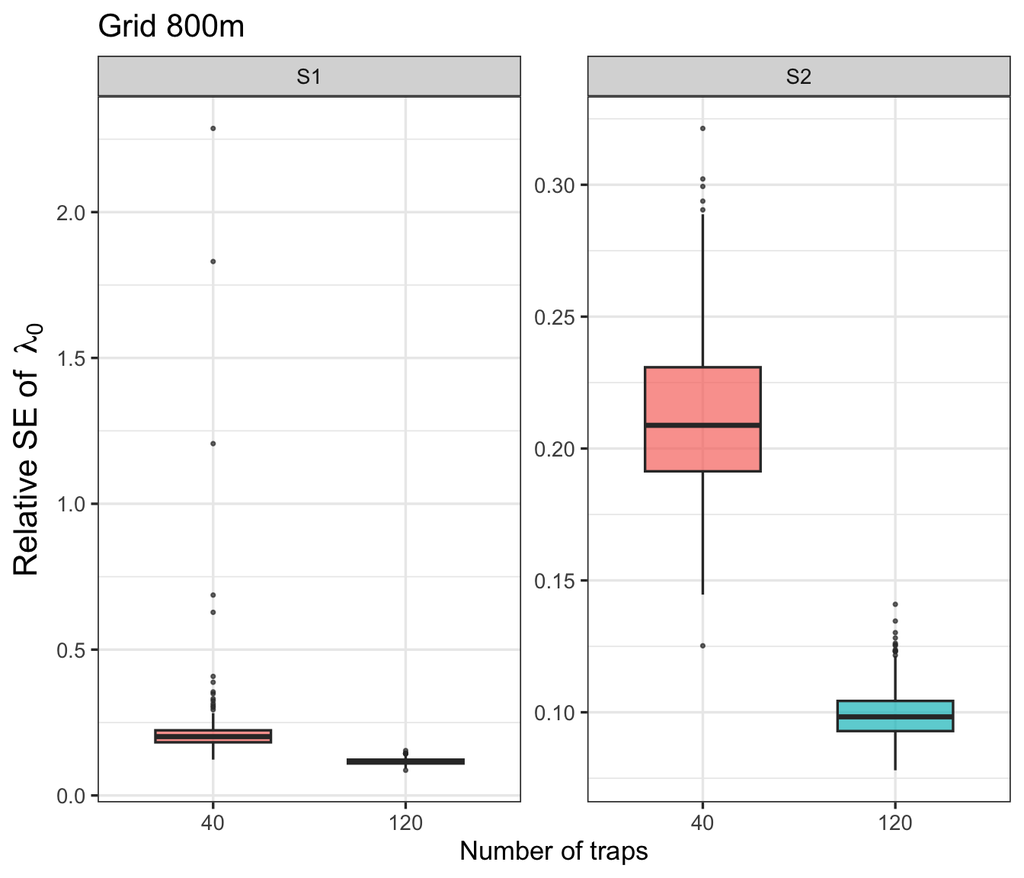

**σ**

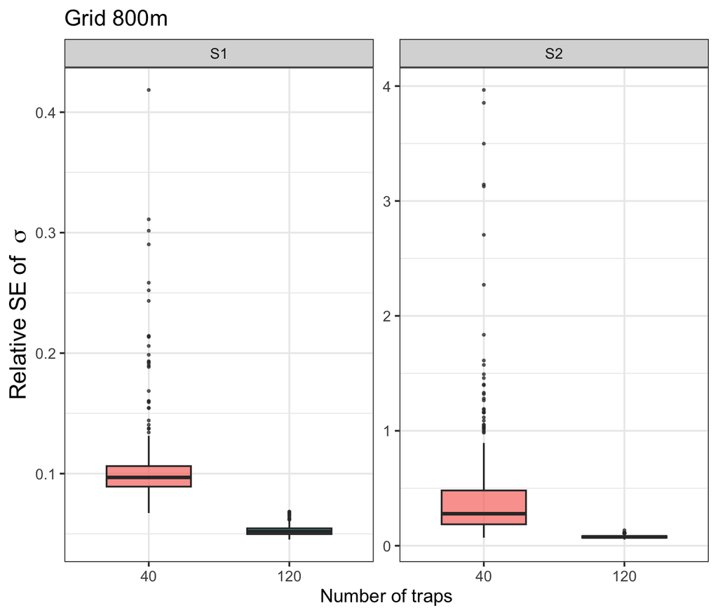

## Grids with 700 m spacing

**Density**

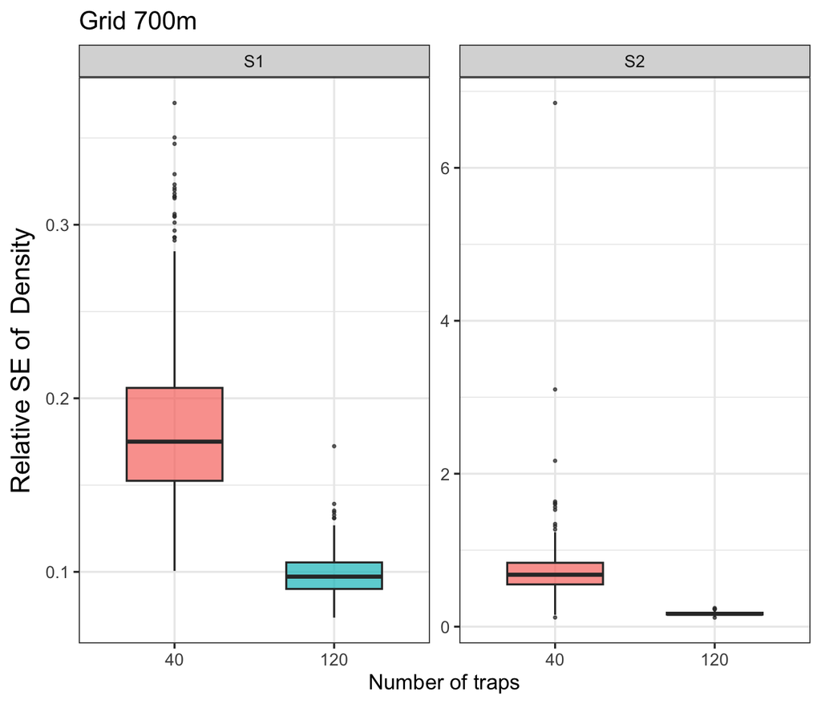

**λ₀**

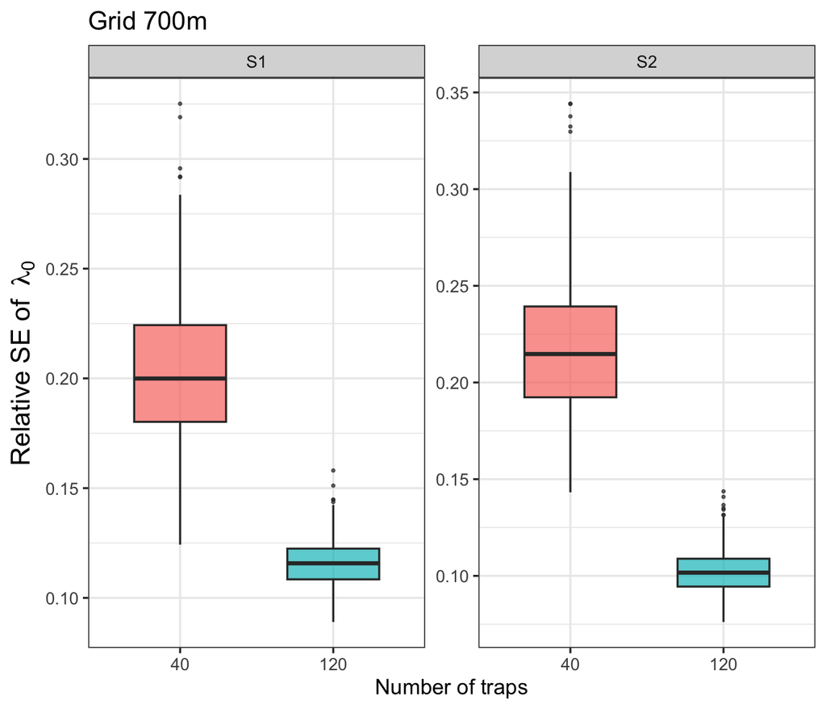

**σ**

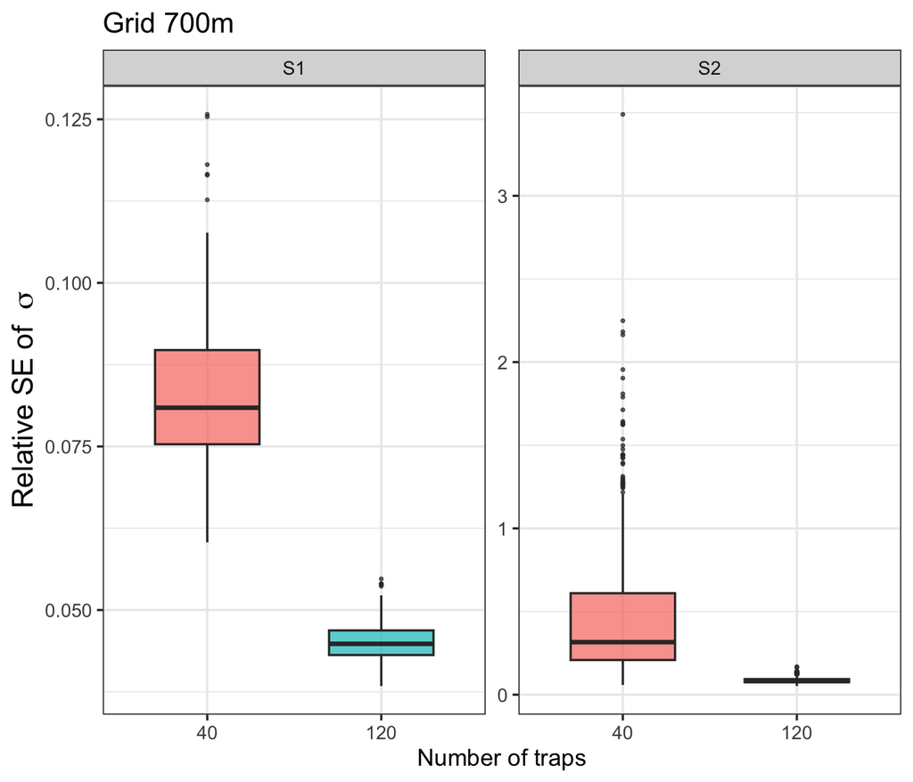

## Clusters - OS spacing

**Density**

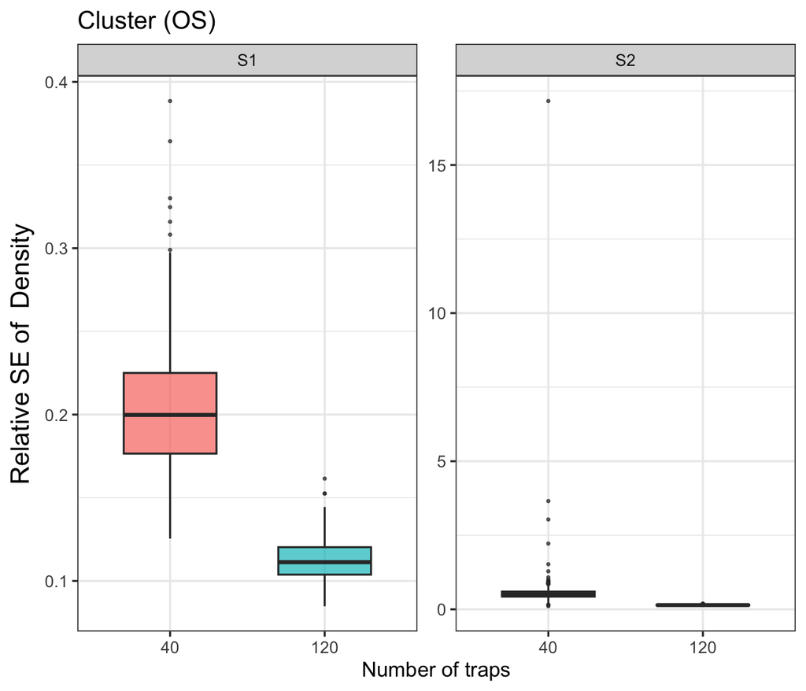

**λ₀**

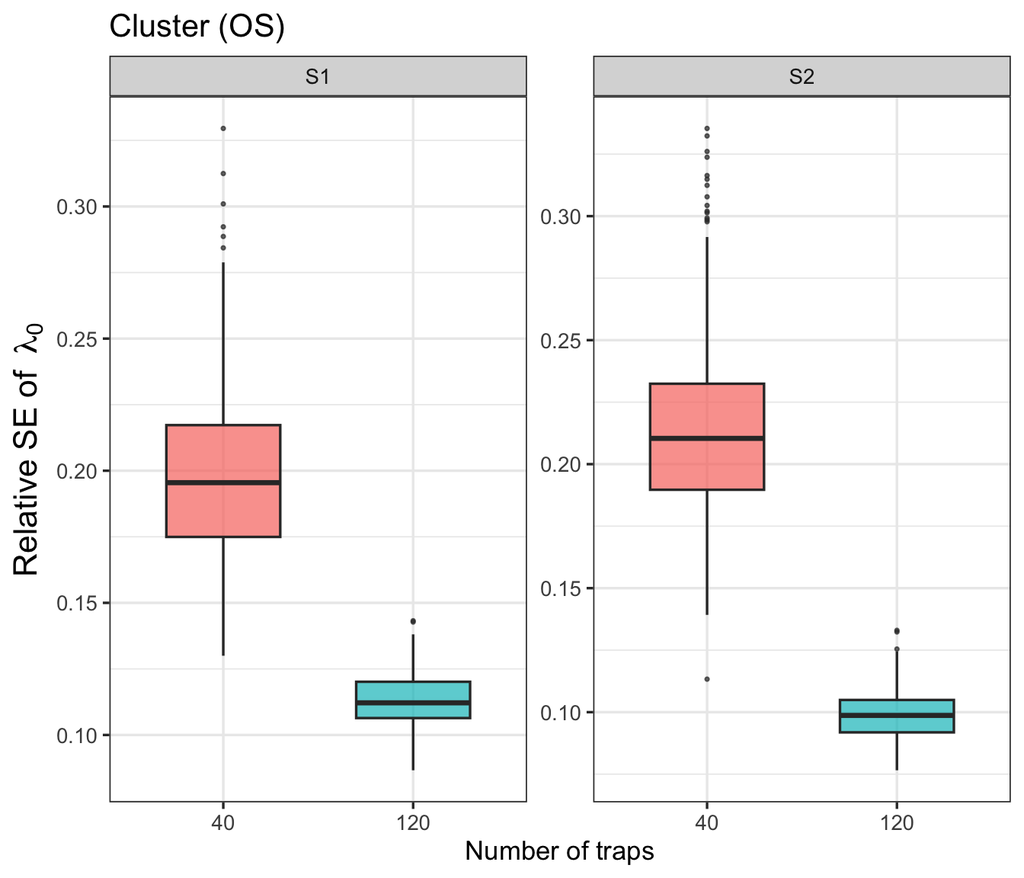

**σ**

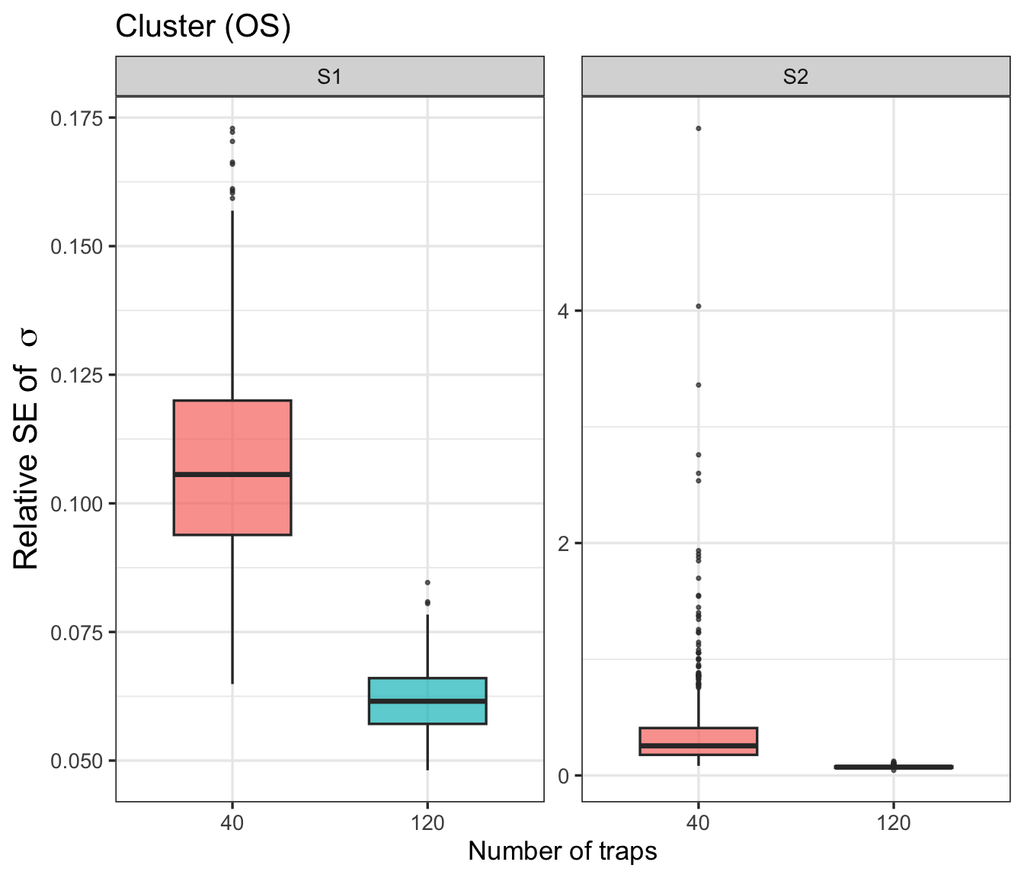

## Clusters - 2 sigma spacing

**Density**

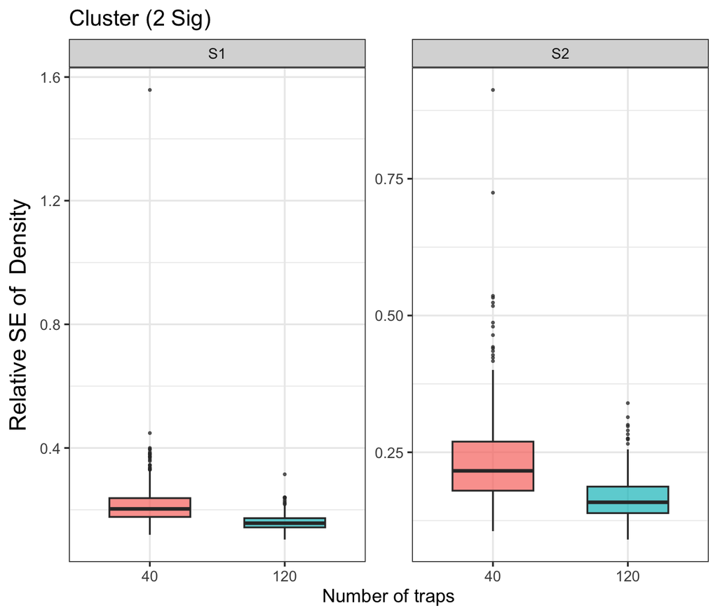

**λ₀**

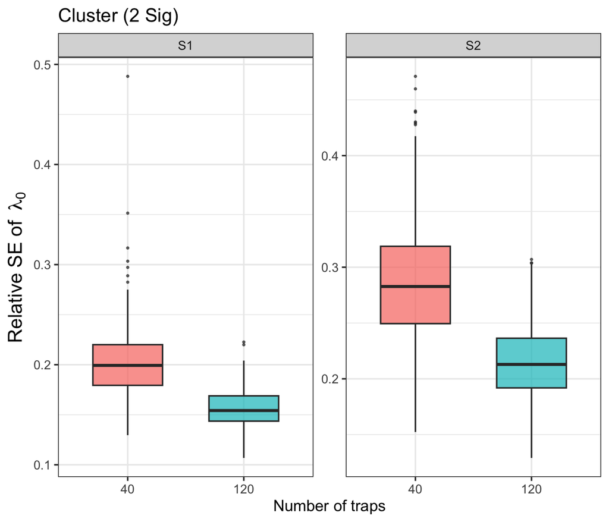

**σ**

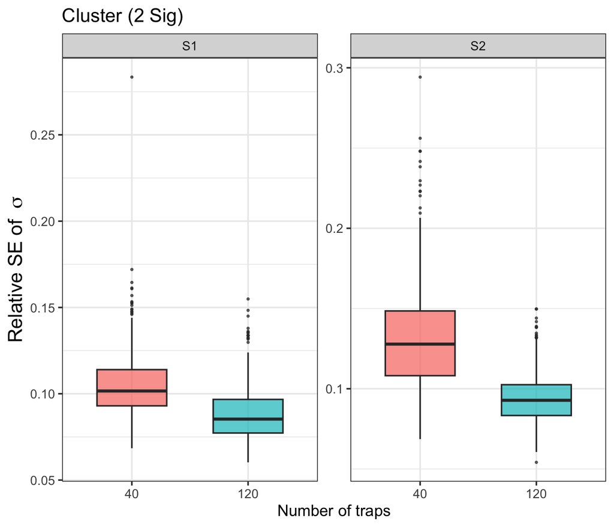

## GA4 - S1 values

**Density**

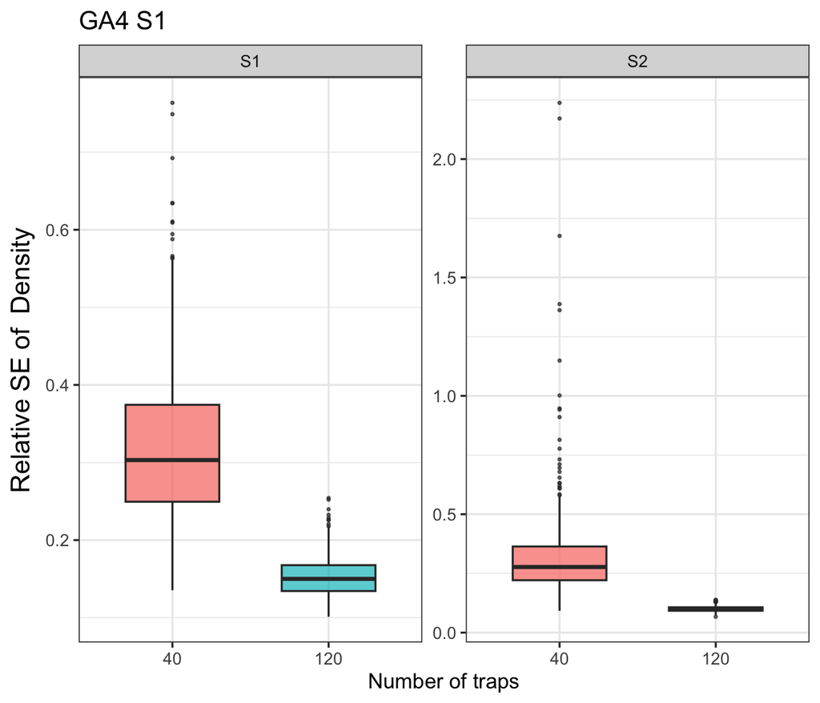

**λ₀**

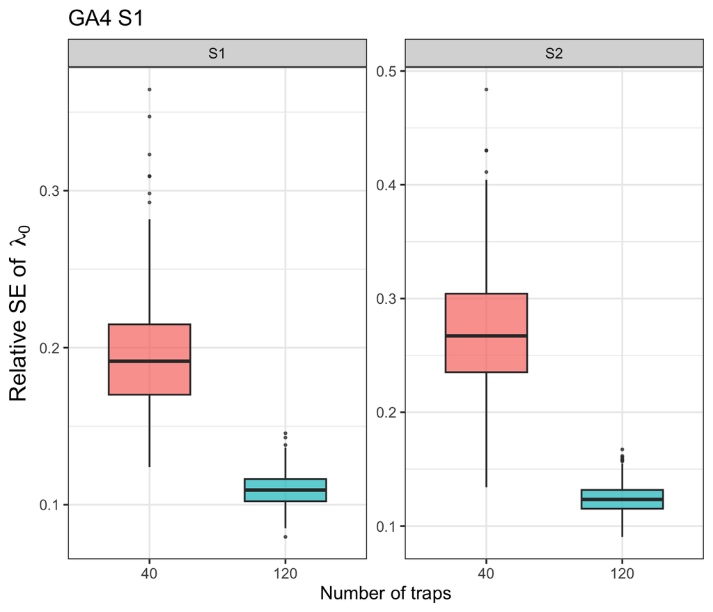

**σ**

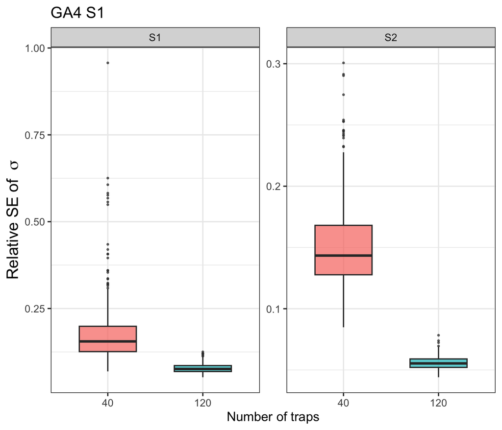

## GA4 - S2 values

**Density**

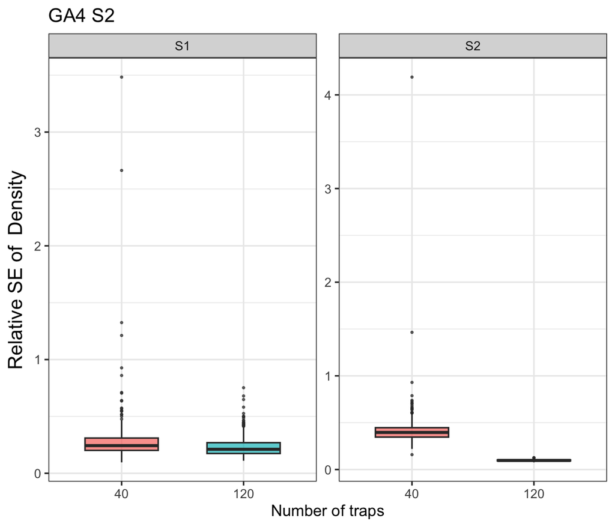

**λ₀**

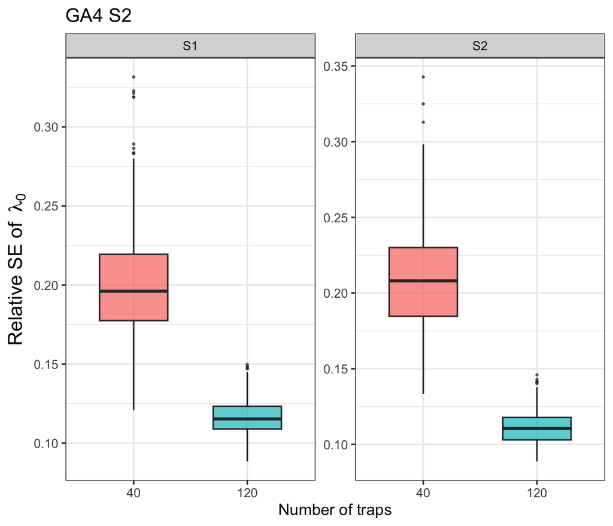

**σ**

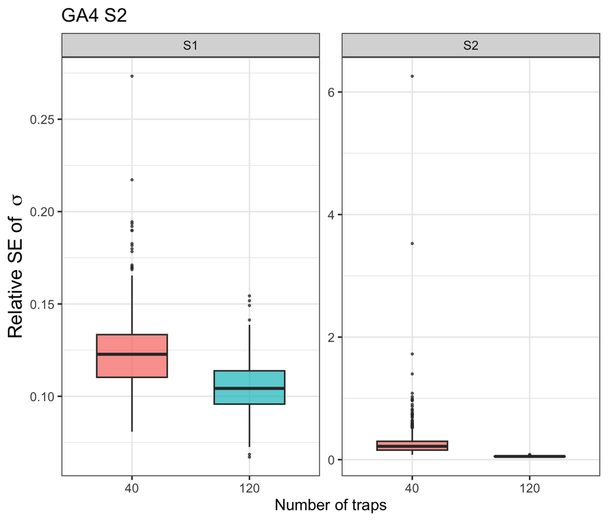

## GA4 - Avg values

**Density**

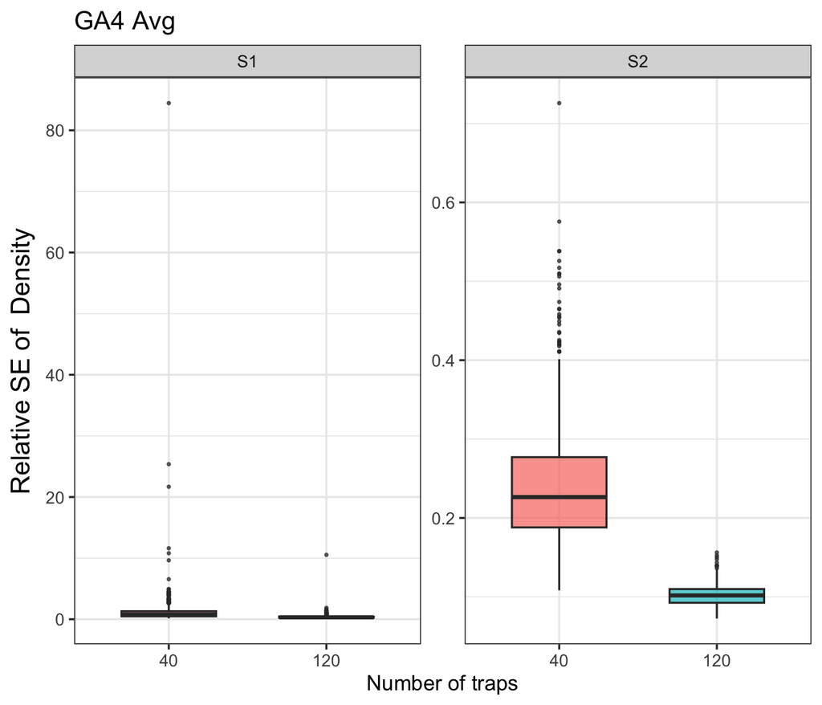

**λ₀**

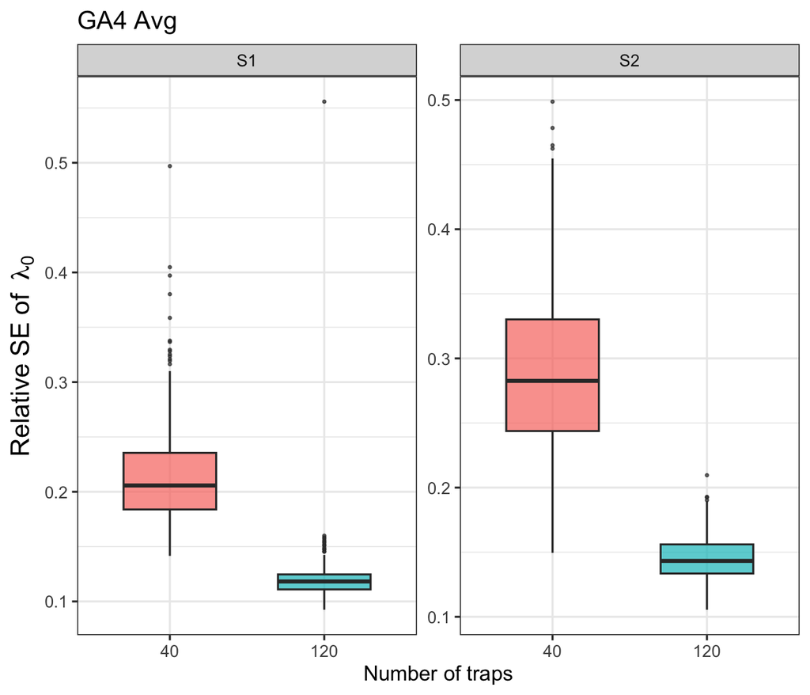

**σ**

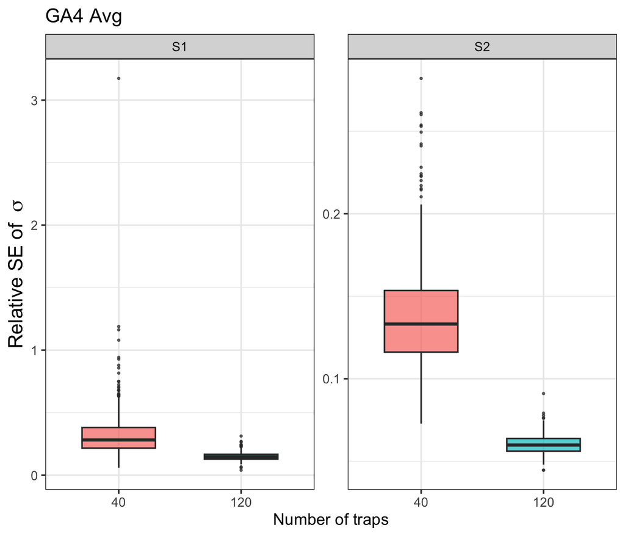